# Import Essential Libraries

```python
import pandas as pd
import numpy as np
import matplotlib.pyplot as plt
import seaborn as sns
%matplotlib inline
```

# Read in Data

```python
# Read in most recent version of Approved Loan Data
approved_df = pd.read_csv('E:/josh_data_science\Lending Club Loan Data/approved_loan_data_ver2.csv',
                          encoding='ISO-8859-1')
```

```python
# Read in most recent version of Approved Loan Data
declined_df = pd.read_csv('E:/josh_data_science\Lending Club Loan Data/declined_loan_data_ver2.csv', encoding='ISO-8859-1')
```

```python
# Remove Unnecessarily created column
del approved_df['Unnamed: 0']
del declined_df['Unnamed: 0']
```

# Preprocessing other Variables

### Loan Amount (loan_amnt, Amount Requested)

##### Approved Loan: loan_amnt

```python
# Number & Proportion of loan amount info that is missing in approved loans data
print(approved_df.loan_amnt.isnull().sum())
print(approved_df.loan_amnt.isnull().sum() / len(approved_df))
```

```
29
1.44704007952e-05
```

Has a pretty good amount of data filled in!

```python
# Summary Stats of loan amounts of approved loan data
approved_df[approved_df.loan_amnt.notnull()].loan_amnt.describe()
```

```
count    2.004062e+06
mean     1.492073e+04
std      9.056246e+03
min      5.000000e+02
25%      8.000000e+03
50%      1.280000e+04
75%      2.000000e+04
max      4.000000e+04
Name: loan_amnt, dtype: float64
```

##### Declined Loan: Amount Requested

```python
# Number & Proportion of loan amount info that is missing in declined loans data
print(declined_df['Amount Requested'].isnull().sum())
print(declined_df['Amount Requested'].isnull().sum() / len(declined_df))
```

```
0
0.0
```

No data missing!

```python
# Summary Statistics of "Amount Requested" for declined loans data
declined_df['Amount Requested'].describe()
```

```
count    2.235336e+07
mean     1.307564e+04
std      1.522336e+04
min      0.000000e+00
25%      4.500000e+03
50%      1.000000e+04
75%      2.000000e+04
max      1.400000e+06
Name: Amount Requested, dtype: float64
```

```
(0, 60000)
```

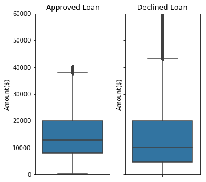

```python
# Boxplots of Applied Loan Amount (approved loan v.s. declined loan)

fig, axes = plt.subplots(nrows=1, ncols=2, sharey= True, figsize=(5, 5))
sns.boxplot(y='loan_amnt', data= approved_df[approved_df.dti.notnull()],ax = axes[0])
axes[0].set_title('Approved Loan')
axes[0].set_ylabel('Amount($)')

sns.boxplot(y='Amount Requested', data=declined_df[declined_df['Amount Requested'].notnull()], ax=axes[1])
axes[1].set_ylabel('Amount($)')
axes[1].set_title('Declined Loan')
plt.ylim(0,60000)
```

### Amount of loan that was actually given out (settlement_amount)

```python
# approved_df.settlement_amount.isnull().sum() / len(df_approved_settlement_date_issue_d_modified)
```

### Risk Evaluation of borrowers (grade, sub_grade / Risk_Score)

###### Risk_Score

```python
# Proportion of risk score info that is missing in declined loans data
declined_df.Risk_Score.isnull().sum() / len(declined_df)
```

```
0.59884837874008712
```

60% of Risk_Score in declined loans data is missing

```python
# Risk Score for approve loans ranging from 0 to 990
declined_df.Risk_Score.describe()
```

```
count    8.967085e+06
mean     6.282897e+02
std      9.023802e+01
min      0.000000e+00
25%      5.920000e+02
50%      6.370000e+02
75%      6.750000e+02
max      9.900000e+02
Name: Risk_Score, dtype: float64
```

###### Approved Loans: grade

```python
# Proportion of grade info that is missing in approved loans data
approved_df.grade.isnull().sum() * 100/ len(approved_df)
```

```
0.0014470400795173473
```

```python
# Unique kinds of values in the "grade" column
set(approved_df.grade.value_counts().index)
```

```
{'A', 'B', 'C', 'D', 'E', 'F', 'G'}
```

So there are 7 different grades for approved loans

###### Approved Loans: sub_grade

```python
approved_df.sub_grade.isnull().sum() * 100/ len(approved_df)
```

```
0.0014470400795173473
```

```python
# 7(A,B,C,D,E,F,G) x 5(1,2,3,4,5) = 35 (e.g. A2, C5...)
len(set(approved_df.sub_grade.value_counts().index))
```

```
35
```

And there are 35 different subgrades for approved loans

Only 0.001% of data for grade and sub_grade is missing

##### We want to see/compare if the distribution of borrowers' credit score is similar for both approved and declined loan data by year

```python
# Creating new variable named "Grade" in declined loan data (binning into 5 different groups depending on fico score)
declined_df['Grade'] = pd.cut(declined_df.Risk_Score.tolist(),bins=[0,550,649,699,750,1000],labels=['A','B','C','D','E'])
```

```python
# Create a new column which has information about Year of Application
declined_df['Application Date Year'] = declined_df['Application Date Year Month'].apply(lambda x: x[:4])
```

```python
# Change datatypes of date variables into integers
# declined_df['Application Date Year Month'] = declined_df['Application Date Year Month'].astype('int')
declined_df['Application Date Year'] = declined_df['Application Date Year'].astype('int')
declined_df['Application Date Month'] = declined_df['Application Date Month'].astype('int')
```

In 2018,

```python
# Percentage Proportion of each credit grade bin for declined loans data in 2018
declined_df[declined_df['Application Date Year']==2018].Grade.value_counts() * 100/ declined_df[declined_df['Application Date Year']==2018].Grade.value_counts().sum()
```

```
B    52.305438
C    25.871844
A     9.805470
D     8.660003
E     3.357246
Name: Grade, dtype: float64
```

```python
# Percentage Proportion of each credit grade bin for approved loans data in 2018
approved_df[approved_df['issue_d_year']==2018].grade.value_counts() * 100/ approved_df[approved_df['issue_d_year']==2018].grade.value_counts().sum()
```

```
B    29.638445
C    26.927622
A    25.052800
D    14.214536
E     3.369148
F     0.672572
G     0.124876
Name: grade, dtype: float64
```

In 2011,

```python
# Percentage Proportion of each credit grade bin for declined loans data in 2011
declined_df[declined_df['Application Date Year']==2011].Grade.value_counts() * 100/ declined_df[declined_df['Application Date Year']==2011].Grade.value_counts().sum()
```

```
B    33.763017
C    29.660509
D    16.282874
A    15.973686
E     4.319915
Name: Grade, dtype: float64
```

```python
# Percentage Proportion of each credit grade bin for approved loans data in 2011
approved_df[approved_df['issue_d_year']==2011].grade.value_counts() * 100/ approved_df[approved_df['issue_d_year']==2011].grade.value_counts().sum()
```

```
B    30.224207
A    26.490493
C    18.148336
D    12.872336
E     8.006077
F     3.323972
G     0.934579
Name: grade, dtype: float64
```

### Debt-to-income ratio (Dti, dti_joint / Debt-to-Income Ratio)

###### Approved Loans: dti

```python
# Proportion of DTI that is null in approved loan data
approved_df.dti.isnull().sum() * 100/ len(approved_df)
```

```
0.059677928796646462
```

```python
# Proportion of DTI_joint that is null in approved loan data
approved_df.dti_joint.isnull().sum() * 100/ len(approved_df)
```

```
95.701841882429491
```

```python
approved_df.dti.describe()
```

```
count    2.002895e+06
mean     1.869026e+01
std      1.318031e+01
min     -1.000000e+00
25%      1.192000e+01
50%      1.783000e+01
75%      2.441000e+01
max      9.990000e+02
Name: dti, dtype: float64
```

There is a negative value for dti in the approved loans data, so I will make that into positive

```python
# Number of observations that have negative dti values
sum(approved_df['dti'] < 0)
```

```
2
```

```python
# Change negative values to positive
approved_df['dti_positive'] = np.where(approved_df['dti'] < 0,
                              (-1)*approved_df['dti'], approved_df['dti'])
```

```python
approved_df['dti'] = approved_df['dti_positive']
```

```python
del approved_df['dti_positive']
```

```python
# Summary Stats again after changing negative values into positive
approved_df['dti'].describe()
```

```
count    2.002895e+06
mean     1.869026e+01
std      1.318031e+01
min      0.000000e+00
25%      1.192000e+01
50%      1.783000e+01
75%      2.441000e+01
max      9.990000e+02
Name: dti, dtype: float64
```

###### Declined Loans: Debt-To-Income

```python
# Proportion of DTI that is null in declined loan data
declined_df['Debt-To-Income Ratio'].isnull().sum() * 100/ len(declined_df)
```

```
0.0
```

```python
# Checking if there is data that is not null but, in fact, equivalent to null
'n/a' in declined_df['Debt-To-Income Ratio']
```

```
False
```

Debt-To-Income Ratio column in the declined loans data is filled with strings, so we need to transform this into float, integer type data. Also, there's the % sign at the end, so we should remove that too!

```python
declined_df['Debt-To-Income Ratio']  = declined_df['Debt-To-Income Ratio'].apply(lambda x: x[:-1])
```

```python
declined_df['Debt-To-Income Ratio']  = declined_df['Debt-To-Income Ratio'].astype('float64')
```

```python
# Summary Stats
declined_df['Debt-To-Income Ratio'].describe()
```

```
count    2.235336e+07
mean     1.533152e+02
std      1.169249e+04
min     -1.000000e+00
25%      7.540000e+00
50%      1.953000e+01
75%      3.587000e+01
max      5.000003e+07
Name: Debt-To-Income Ratio, dtype: float64
```

The minimum dti in the declined loans data is a negative number...?!

```python
sum(declined_df['Debt-To-Income Ratio'] < 0)
```

```
1136013
```

There are 1136013 negative values... It doesn't make sense to have negative values for dti, so let's switch them to positive

```python
# Change negative values to positive
declined_df['dti'] = np.where(declined_df['Debt-To-Income Ratio'] < 0,
                              (-1)*declined_df['Debt-To-Income Ratio'], declined_df['Debt-To-Income Ratio'])
```

```python
declined_df['dti'].describe()
```

```
count    2.235336e+07
mean     1.534169e+02
std      1.169249e+04
min      0.000000e+00
25%      7.540000e+00
50%      1.953000e+01
75%      3.587000e+01
max      5.000003e+07
Name: dti, dtype: float64
```

However, the max value seems to be too large to be true. A borrower whose debt is 50000030% of his or her income? The maximum dti for the approved loans was 999 and let's see how many borrowers in the rejected loans data have dti over 999.

```python
# 0.64% of borrowers whose loan application has been rejected has dti over 999
sum(declined_df['dti'] > 999) * 100 / len(declined_df)
```

```
0.64688273206045666
```

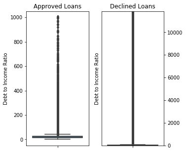

```python
# Boxplot comparison of dti between approved loan and declined loan data
fig, axes = plt.subplots(nrows=1, ncols=2, figsize=(5, 5))
sns.boxplot(y='dti', data= approved_df[approved_df.dti.notnull()],ax = axes[0])
axes[0].set_ylabel('Debt to Income Ratio')
axes[0].set_title('Approved Loans')

sns.boxplot(y='dti', data=declined_df[declined_df['dti'].notnull()], ax=axes[1])
axes[1].set_ylabel('Debt to Income Ratio')
axes[1].set_title('Declined Loans')
axes[1].set_ylim(0,11845.9069)
axes[1].yaxis.tick_right()
```